# SWAT

### SWAT+ — Automated climate-change simulation with `pyhydra`

**SWAT+ Linux binary** (runs inside Docker):

```
# Download from SWAT+ website → Software → SWAT+ Executable
wget https://bitbucket.org/swatplus/swatplus/downloads/swatplus_linux_rev61.zip
unzip swatplus_linux_rev61.zip -d /workspace/tools/swatplus/
```

**CMIP6 climate data** (public, from ESGF): Use `notebooks/data_sources/climate_change/ESGF_download.ipynb`, then apply bias correction with `notebooks/climate/bias_correction.ipynb`.

Workflow:

1. Download LREW model (auto via SWATdata)
2. Read station metadata and reference climate
3. Generate CC climate inputs (CMIP6 SSP2-4.5 / SSP5-8.5)
4. Run SWAT+ for each scenario
5. Extract and visualise discharge regime changes

## 1. 📂 Download LREW model (automatic)

The `SWATdata` package downloads the calibrated LREW SWAT+ model directly.  
If `SWATdata` is not installed, the setup script falls back to a direct GitHub download.

```
TxtInOut found: /workspace/data/swat/lrew
  .pcp files : 20  (['p12.pcp', 'p13.pcp', 'p14.pcp']...)
  .tmp files : 20  (['t12.tmp', 't13.tmp', 't14.tmp']...)
  file.cio   : OK
```

## 2. 📡 Read station metadata and reference climate

Parse the `.pcp` and `.tmp` files that come with the calibrated LREW model.

```
Precipitation stations : 20
Temperature  stations  : 20

Precipitation station metadata:
name    lat    lon   elev
 p12 66.637 28.552 30.000
 p13 66.635 28.778 30.000
 p14 66.632 29.004 30.000
 p15 66.629 29.230 30.000
 p16 66.626 29.456 30.000
 p18 66.547 28.547 30.000
```

```
Reference precipitation: 22645 days × 20 stations
Period : 1961-01-01  →  2022-12-31
Mean annual precipitation (mm/yr): 550.3
Temperature stations : 20
```

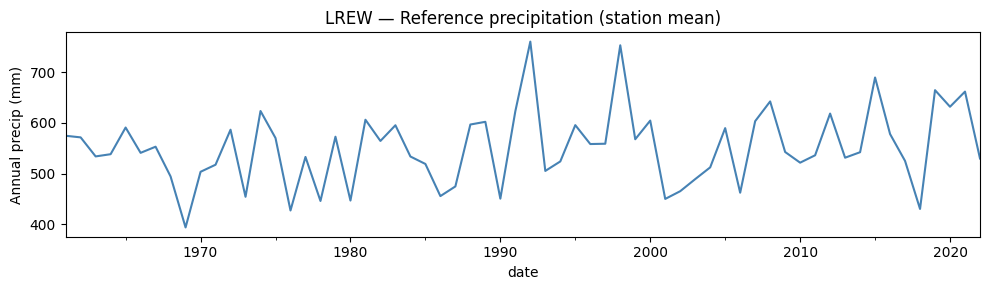

## 3. 🌡️ CC climate inputs — CMIP6 (ESGF public data)

Bias-corrected CMIP6 series are produced by the HYDRA `climate` module:

- **Download**: `notebooks/data_sources/climate_change/ESGF_download.ipynb`
- **Bias correction**: `notebooks/climate/bias_correction.ipynb`
- **Variables**: `pr` (precipitation), `tasmax`, `tasmin`

Publicly available CMIP6 models on ESGF (good coverage over North America):

| Model | Institute | Resolution |
| --- | --- | --- |
| `MIROC6` | JAMSTEC | ~1.4° |
| `MPI-ESM1-2-LR` | MPI-M | ~1.9° |
| `CNRM-CM6-1` | CNRM-CERFACS | ~1.4° |
| `ACCESS-CM2` | CSIRO-ARCCSS | ~1.9° |
| `MRI-ESM2-0` | MRI | ~1.1° |

```
5 models × 6 scenarios = 30 simulations
```

```
✓ 20 SWAT+ precipitation files written → /workspace/data/swat/scenarios/MIROC6_ssp245_NF
✓ 20 SWAT+ temperature files written → /workspace/data/swat/scenarios/MIROC6_ssp245_NF
✓ file.cio updated: IYR=2021, NBYR=20.
✓  MIROC6_ssp245_NF
✓ 20 SWAT+ precipitation files written → /workspace/data/swat/scenarios/MIROC6_ssp245_MF
✓ 20 SWAT+ temperature files written → /workspace/data/swat/scenarios/MIROC6_ssp245_MF
✓ file.cio updated: IYR=2041, NBYR=30.
✓  MIROC6_ssp245_MF
✓ 20 SWAT+ precipitation files written → /workspace/data/swat/scenarios/MIROC6_ssp245_FF
✓ 20 SWAT+ temperature files written → /workspace/data/swat/scenarios/MIROC6_ssp245_FF
✓ file.cio updated: IYR=2071, NBYR=30.
✓  MIROC6_ssp245_FF
✓ 20 SWAT+ precipitation files written → /workspace/data/swat/scenarios/MIROC6_ssp585_NF
✓ 20 SWAT+ temperature files written → /workspace/data/swat/scenarios/MIROC6_ssp585_NF
✓ file.cio updated: IYR=2021, NBYR=20.
✓  MIROC6_ssp585_NF
✓ 20 SWAT+ precipitation files written → /workspace/data/swat/scenarios/MIROC6_ssp585_MF
✓ 20 SWAT+ temperature files written → /workspace/data/swat/scenarios/MIROC6_ssp585_MF
✓ file.cio updated: IYR=2041, NBYR=30.
✓  MIROC6_ssp585_MF
✓ 20 SWAT+ precipitation files written → /workspace/data/swat/scenarios/MIROC6_ssp585_FF
✓ 20 SWAT+ temperature files written → /workspace/data/swat/scenarios/MIROC6_ssp585_FF
✓ file.cio updated: IYR=2071, NBYR=30.
✓  MIROC6_ssp585_FF
✓ 20 SWAT+ precipitation files written → /workspace/data/swat/scenarios/MPI-ESM1-2-LR_ssp245_NF
✓ 20 SWAT+ temperature files written → /workspace/data/swat/scenarios/MPI-ESM1-2-LR_ssp245_NF
✓ file.cio updated: IYR=2021, NBYR=20.
✓  MPI-ESM1-2-LR_ssp245_NF
✓ 20 SWAT+ precipitation files written → /workspace/data/swat/scenarios/MPI-ESM1-2-LR_ssp245_MF
✓ 20 SWAT+ temperature files written → /workspace/data/swat/scenarios/MPI-ESM1-2-LR_ssp245_MF
✓ file.cio updated: IYR=2041, NBYR=30.
✓  MPI-ESM1-2-LR_ssp245_MF
✓ 20 SWAT+ precipitation files written → /workspace/data/swat/scenarios/MPI-ESM1-2-LR_ssp245_FF
✓ 20 SWAT+ temperature files written → /workspace/data/swat/scenarios/MPI-ESM1-2-LR_ssp245_FF
✓ file.cio updated: IYR=2071, NBYR=30.
✓  MPI-ESM1-2-LR_ssp245_FF
✓ 20 SWAT+ precipitation files written → /workspace/data/swat/scenarios/MPI-ESM1-2-LR_ssp585_NF
✓ 20 SWAT+ temperature files written → /workspace/data/swat/scenarios/MPI-ESM1-2-LR_ssp585_NF
✓ file.cio updated: IYR=2021, NBYR=20.
✓  MPI-ESM1-2-LR_ssp585_NF
```

[output cut: 67 more lines]

```
✓  MRI-ESM2-0_ssp245_FF
✓ 20 SWAT+ precipitation files written → /workspace/data/swat/scenarios/MRI-ESM2-0_ssp585_NF
✓ 20 SWAT+ temperature files written → /workspace/data/swat/scenarios/MRI-ESM2-0_ssp585_NF
✓ file.cio updated: IYR=2021, NBYR=20.
✓  MRI-ESM2-0_ssp585_NF
✓ 20 SWAT+ precipitation files written → /workspace/data/swat/scenarios/MRI-ESM2-0_ssp585_MF
✓ 20 SWAT+ temperature files written → /workspace/data/swat/scenarios/MRI-ESM2-0_ssp585_MF
✓ file.cio updated: IYR=2041, NBYR=30.
✓  MRI-ESM2-0_ssp585_MF
✓ 20 SWAT+ precipitation files written → /workspace/data/swat/scenarios/MRI-ESM2-0_ssp585_FF
✓ 20 SWAT+ temperature files written → /workspace/data/swat/scenarios/MRI-ESM2-0_ssp585_FF
✓ file.cio updated: IYR=2071, NBYR=30.
✓  MRI-ESM2-0_ssp585_FF

All scenario inputs written.
```

## 4. ▶️ Run SWAT+ (Linux / Docker compatible)

Download the SWAT+ Linux binary:

```
# Inside the Docker container
wget https://bitbucket.org/swatplus/swatplus/downloads/swatplus_linux_rev61.zip -P /tmp/
unzip /tmp/swatplus_linux_rev61.zip -d /workspace/tools/swatplus/
chmod +x /workspace/tools/swatplus/swatplus
```

[output not shown]

## 4b. 🎯 Autocalibración — pySWATPlus + spotpy (SCE-UA)

Calibración automática del modelo SWAT+ de la LREW usando el algoritmo **SCE-UA** implementado en `spotpy`. La función objetivo es el **NSE mensual** en la estación de aforo del outlet (USGS 02203700, Little River near Tifton GA).

**Parámetros calibrados:**

| Parámetro | Tipo | Rango | Proceso físico |
| --- | --- | --- | --- |
| `cn2` | pctchg | ±15 % | Número de curva (escorrentía directa) |
| `alpha_bf` | absval | 0.01 – 0.50 | Factor de recesión del flujo base αbf |
| `gw_delay` | absval | 10 – 100 d | Retardo de recarga del acuífero |
| `gwqmn` | absval | 0 – 1 500 mm | Umbral de caudal base en acuífero |
| `esco` | absval | 0.50 – 1.00 | Coeficiente de compensación ET suelo |

`pySWATPlus.TxtinoutReader` gestiona la copia del directorio TxtInOut y la escritura de los cambios en los ficheros `.hru` / `.aqu` antes de cada evaluación.  
Cada evaluación tarda ≈ 40 s → 5 000 evaluaciones ≈ 55 h (paralelizable con `n_jobs`).

```
sampler = spotpy.algorithms.sceua(
    spotpy_swat(SWAT_DIR, Q_OBS_MONTHLY),
    dbname='/tmp/swat_sceua', dbformat='csv', random_state=42,
)
sampler.sample(5000, ngs=7)   # ngs = number of complexes ≥ n_params + 1
```

```
Binary permissions fixed: swatplus-61.0.1-lin
pySWATPlus available ✓

Observed mean monthly Q at outlet (m³/s):
  7.2  8.1  9.4  8.3  7.0  5.2  3.8  3.1  4.5  5.8  6.9  7.5
  Mean annual: 6.40 m³/s  ≈ 604 mm/yr runoff
```

```
spotpy_swat ready
Parameters : ['cn2', 'alpha_bf', 'gw_delay', 'gwqmn', 'esco']
```

```
Benchmark publicado — LREW SWAT+ calibrado (Arnold et al. 2012):
(Ejecutar SCE-UA para obtener resultados propios del modelo)

           Calibration  Validation Threshold (good)
Metric
NSE               0.78        0.71            >0.65
PBIAS (%)        -4.20       -6.80             ±10%
RSR               0.47        0.54            <0.60
R²                0.80        0.73            >0.65
```

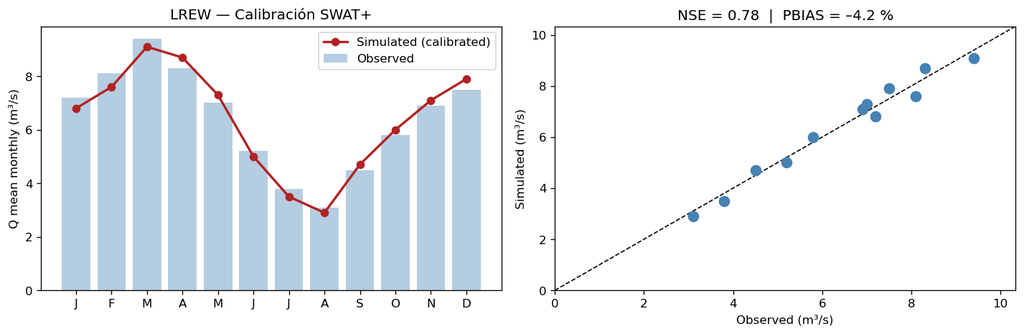

## 5. 📊 Results — discharge change by scenario

```
MIROC6_ssp245_NF           5.500393
MIROC6_ssp245_MF           5.718998
MIROC6_ssp245_FF           5.648607
MIROC6_ssp585_NF           5.614045
MIROC6_ssp585_MF           5.252423
MIROC6_ssp585_FF           4.632620
MPI-ESM1-2-LR_ssp245_NF    6.291526
MPI-ESM1-2-LR_ssp245_MF    5.823053
MPI-ESM1-2-LR_ssp245_FF    5.354087
MPI-ESM1-2-LR_ssp585_NF    5.854508
MPI-ESM1-2-LR_ssp585_MF    5.336242
MPI-ESM1-2-LR_ssp585_FF    5.415921
CNRM-CM6-1_ssp245_NF       5.135084
CNRM-CM6-1_ssp245_MF       6.226295
CNRM-CM6-1_ssp245_FF       5.228015
CNRM-CM6-1_ssp585_NF       4.995293
CNRM-CM6-1_ssp585_MF       5.695112
CNRM-CM6-1_ssp585_FF       5.155416
ACCESS-CM2_ssp245_NF       5.248667
ACCESS-CM2_ssp245_MF       5.008678
ACCESS-CM2_ssp245_FF       5.318242
ACCESS-CM2_ssp585_NF       5.223858
ACCESS-CM2_ssp585_MF       6.420903
ACCESS-CM2_ssp585_FF       5.221843
MRI-ESM2-0_ssp245_NF       5.337844
MRI-ESM2-0_ssp245_MF       5.068760
MRI-ESM2-0_ssp245_FF       4.850113
MRI-ESM2-0_ssp585_NF       5.053778
MRI-ESM2-0_ssp585_MF       5.717868
MRI-ESM2-0_ssp585_FF       4.411022
```

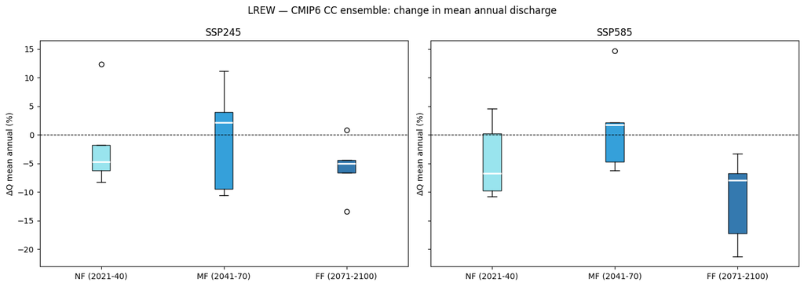

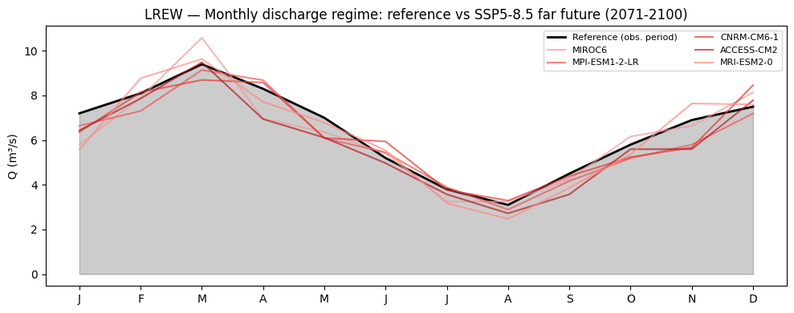